# Exploración de datos y visualización en R

Sesión III - Práctico

# 1 Introducción

En el siguiente práctico aplicaremos las técnicas y conceptos que hemos desarrollado en las sesiones I y II teórico-prácticas del taller de visualización y análisis en R, aplicados a estádistica. Para este práctico utilizaremos el set de datos para el análisis de ataque cardíaco llamado **heart**. El set de datos contiene información sobre 303 pacientes -hombres (207) y mujeres (96)- entre 29 y 77 años, junto a análisis fisiologicos orientados al diagnóstico y estudio de un ataque cardíaco. Realizaremos un análisis exploratorio de datos o *EDA* para generar preguntas y obtener algunas conclusiones desde nuestro set de datos. Con esa finalidad, al igual que en la sesión II, dividiremos el análisis en dos, según si las estrategias para la visualización y análisis se encuentran más orientadas en la estadística descriptiva (comprender nuestro set de datos) o en la inferencia estadística (testear hipótesis).

# 2 Análisis exploratorio de datos o **EDA**

¿Qué es un análisis exploratorio de datos?  
Recordemos en que consiste un análisis exploratorio de datos. El análisis exploratorio de datos o “EDA” (por sus siglas en inglés **E**xploratory **D**ata **A**nalysis), es como se conoce -en estadística- el proceso por el cual un investigador inspecciona un set de datos con la finalidad de generar preguntas, procesar y adquirir conocimiento (procesa datos, genera resultados), y refina o genera nuevas preguntas.

¿Cúal es el proceso iterativo?

1. Generar preguntas basandose en los datos.
2. Obtener resultados (procesa datos, gráficos, modelos, etc.).
3. Refinar preguntas y/o generar nuevas preguntas.

Consideraciones durante el **EDA**  
Recordemos que si bien el nombre puede generar la impresión de un proceso estandarizado, en la práctica no hay reglas que limiten los análisis o técnicas utilizadas para generar el proceso iterativo. Sin embargo, existen análisis que se vuelven recurrentes durante el proceso.

“Far better an approximate answer to the right question, which is often vague, than an exact answer to the wrong question, which can always be made precise.”

*John Tukey*

## 2.1 Requisitos de nuestro análisis

Acá podrás encontrar todas las librerías que utilizaremos en nuestro análisis. Recuerda que es necesario que se encuentren instaladas en tú sesión de **R** y que al comenzar el análsis le digas a **R** que tiene que cargar esas librerías en la memoría y así permitir el uso de sus funciones.

```r
# El primer paso será cargar las librerías que usaremos en el análisis.
# En caso de que no las hayas instalado aún, primero deberas descomentar
# "eliminar el # a la izquierda de source(...)" y correr el siguiente comando:
#source("https://tamayoleivaj.github.io/Dataviz_R_PUCV_2021/Dataviz_R_PUCV_2021.R")
library(tidyverse)
library(gtsummary)
```

## 2.2 El set de datos **heart**

Como mencionamos anteriormente en nuestra sesión III utilizaremos el set de datos para el análisis de ataque cardíaco llamado **heart**. En este set encontraremos información sobre 303 pacientes -hombres (207) y mujeres (96)- con edades entre los 29 y 77 años. Sin embargo, el set de datos **heart** también cuenta con información asociada a cada paciente, como el dolor de angina un tipo de dolor de pecho ocasionado por una disminución de la irrigación sanguínea al corazón. Además del tipo de angina, tendremos que investigar como otras variables contenidas en el set de datos pueden ser utilizadas para estudio de un ataque cardíaco. A continuación se describe como cargar el set de datos en tú sesión de **R** y una descripción de la información contenida en el set de datos **heart**.

### 2.2.1 Cargar el set de datos

A continuación podrán descargar el set de datos **heart** en dos formatos -**csv** *comma-separated values* y/o **rds** *R data serialized*-. El formato **csv** es un formato de texto plano donde los datos se encuentran separados en columnas mediante comas “,”, mientras que el formato **rds** es propio de **R** y tiene las ventajas de a) estar comprímido (“gzip”) y b) tener mayor compatibilidad, lo que permitirá realizar el práctico independiente del sistema operativo en su computador o su configuración local.

¿Cómo cargar los datos en mi sesión de **R**?  
**Opción A**) Si descargas el “heart.csv” la función que debes ocupar es la siguiente:

```r
heart <- read_csv("./heart.csv")
```

**Opción B**) Si descargas el “heart.rds” la función que debes ocupar es la siguiente:

```r
heart <- read_rds("./heart.rds")
```

### 2.2.2 Información sobre el set de datos

- **age** : Edad del paciente
- **sex** : Sexo del paciente (Mujer; Hombre)
- **cp** : Tipo de dolor de pecho (angina)
  - Value 0: asintomático
  - Value 1: angina típica
  - Value 2: angina atípica
  - Value 3: dolor no anginoso
- **trtbps** : Presión arterial en reposo (en mm Hg al ingreso en el hospital)
- **chol** : Colesterol en mg/dl obtenido a través del sensor de IMC
- **fbs** : (azúcar en sangre en ayunas >120 mg/dl) (1 = true; 0 = false)
- **restecg** : Resultados electrocardiográficos en reposo.
  - Value 0: Normal
  - Value 1: Anomalía de la onda ST-T (inversiones de la onda T y / o elevación o depresión del ST de> 0,05 mV)
  - Value 2: Muestra hipertrofia ventricular izquierda probable o definitiva según los criterios de Estes.
- **thalach** : Frecuencia cardíaca máxima alcanzada.
- **exng** : Angina inducida por ejercicio (1 = si; 0 = no).
- **oldpeak** : Depresión del ST inducida por el ejercicio en relación con el reposo.
- **slp** : Pendiente del segmento ST de ejercicio máximo.
  - Value o: descendente
  - Value 1: plano
  - Value 2: ascendente
- **caa** : Número de vasos principales (0-4) coloreados por fluoroscopia.
- **thall**: Frecuencia cardíaca ritmo.
  - Value 1: defecto fijo
  - Value 2: normal
  - Value 3: defecto reversible
- **output** : 0 = menos probabilidad de ataque cardíaco. 1 = más probabilidad de ataque cardíaco

Sobre la base de las variables contenidas en el set de datos **heart**, ya podríamos dirigir el análisis hacia aquellas variables que son intuitivamente más relevante en el diagnóstico de un ataque al corazón. Podríamos generar algunas de las siguientes preguntas:

1. ¿Cuáles son las variables más importantes de nuestro análisis?
2. ¿Cómo se relaciona la edad (**age**) del paciente con un ataque al corazón?
3. ¿Cómo se relaciona el sexo (**sex**) del paciente con un ataque al corazón?
4. ¿Cómo se relaciona el colesterol (**chol**) del paciente con un ataque al corazón?
5. ¿Cómo se relaciona la presión arterial en reposo (**trtbps**) o la frecuencia cardíaca máxima alcanzada (**thalach**) del paciente con un ataque al corazón?

# 3 Estadística descriptiva

## 3.1 Tablas de resumen

Pero antes de resolver estas preguntas, lo primero que haremos será realizar un pequeño análisis descriptivo de los valores contenidos en las variables continuas del set de datos **heart**. Las variables serán seleccionadas con la función `select(...)`.

```r
heart %>%
   select(age, trtbps, chol, fbs, thalachh, oldpeak, caa) %>%
    summary()
```

```
      age            trtbps           chol            fbs
 Min.   :29.00   Min.   : 94.0   Min.   :126.0   Min.   :0.0000
 1st Qu.:47.50   1st Qu.:120.0   1st Qu.:211.0   1st Qu.:0.0000
 Median :55.00   Median :130.0   Median :240.0   Median :0.0000
 Mean   :54.37   Mean   :131.6   Mean   :246.3   Mean   :0.1485
 3rd Qu.:61.00   3rd Qu.:140.0   3rd Qu.:274.5   3rd Qu.:0.0000
 Max.   :77.00   Max.   :200.0   Max.   :564.0   Max.   :1.0000
    thalachh        oldpeak          caa
 Min.   : 71.0   Min.   :0.00   Min.   :0.0000
 1st Qu.:133.5   1st Qu.:0.00   1st Qu.:0.0000
 Median :153.0   Median :0.80   Median :0.0000
 Mean   :149.6   Mean   :1.04   Mean   :0.7294
 3rd Qu.:166.0   3rd Qu.:1.60   3rd Qu.:1.0000
 Max.   :202.0   Max.   :6.20   Max.   :4.0000
```

A continuación usaremos las funciones del paquete {[gtsummary](http://www.danieldsjoberg.com/gtsummary/)} para generar una tabla descriptiva con mayor detalle. Para facilitar la interpretación de los datos, los nombres de las variables serán modificadas en la tabla con la opción `label = list(...)`.

```r
heart %>%
  select(age, sex, trtbps, chol, thalachh, oldpeak, caa) %>%
  tbl_summary(
    by = sex,
    label = list(age ~ "Edad del paciente",
                 trtbps ~ "Presión arterial en reposo (en mm Hg)",
                 chol ~ "Colesterol en mg/dl",
                 thalachh ~ "Frecuencia cardíaca máxima alcanzada",
                 oldpeak ~ "Depresión del ST",
                 caa ~ "Número de vasos principales (0-4)"),
    type = all_continuous() ~ "continuous2",
    statistic = all_continuous() ~ c("{mean} ({sd})","{p25} - {p75}","{min} - {max}")
  )
```

| **Characteristic** | **Hombre**, N = 207 | **Mujer**, N = 96 |
| --- | --- | --- |
| Edad del paciente |  |  |
| Mean (SD) | 54 (9) | 56 (9) |
| IQR | 47 - 60 | 50 - 63 |
| Range | 29 - 77 | 34 - 76 |
| Presión arterial en reposo (en mm Hg) |  |  |
| Mean (SD) | 131 (17) | 133 (19) |
| IQR | 120 - 140 | 120 - 140 |
| Range | 94 - 192 | 94 - 200 |
| Colesterol en mg/dl |  |  |
| Mean (SD) | 239 (43) | 261 (65) |
| IQR | 208 - 268 | 215 - 297 |
| Range | 126 - 353 | 141 - 564 |
| Frecuencia cardíaca máxima alcanzada |  |  |
| Mean (SD) | 149 (24) | 151 (20) |
| IQR | 132 - 168 | 141 - 165 |
| Range | 71 - 202 | 96 - 192 |
| Depresión del ST |  |  |
| Mean (SD) | 1.12 (1.17) | 0.88 (1.12) |
| IQR | 0.00 - 1.80 | 0.00 - 1.40 |
| Range | 0.00 - 5.60 | 0.00 - 6.20 |
| Número de vasos principales (0-4) |  |  |
| 0 | 111 (54%) | 64 (67%) |
| 1 | 50 (24%) | 15 (16%) |
| 2 | 25 (12%) | 13 (14%) |
| 3 | 16 (7.7%) | 4 (4.2%) |
| 4 | 5 (2.4%) | 0 (0%) |

## 3.2 Visualizando distribuciones

A continuación usaremos las funciones del paquete {[ggplot2](https://ggplot2.tidyverse.org/reference/index.html)} para generar gráficos descriptivos de las variables continuas del set de datos **heart**.

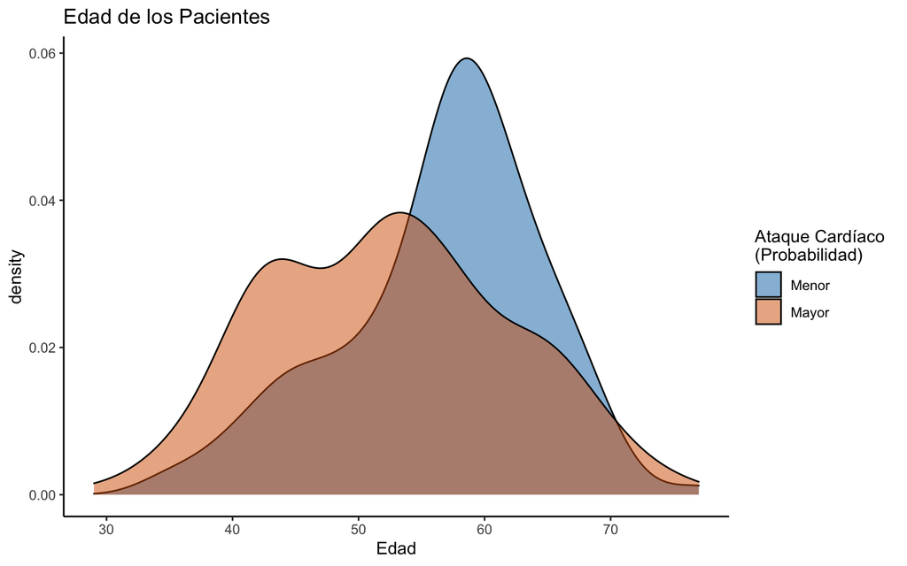

```r
ggplot(data = heart,
       aes(x = age, fill = as.character(output))) +
  geom_density(alpha=0.5) +
  scale_fill_manual(label = c("0"="Menor","1"="Mayor"),
                    values = c("0"="#0072B2","1"="#D55E00")) +
  theme_classic() +
  labs(title = "Edad de los Pacientes",
       x="Edad",
       fill="Ataque Cardíaco \n(Probabilidad)")
```

El factor `alpha=...` ajusta la transparencia del color, en la función anterior el valor fue ajustado al 50% (0.5). Recordemos que el factor **output** (probabilidad de ataque cardíaco) corresponde a una escala discreta representada por “0” (menor) y “1” (mayor), para remplazar la leyenda hemos ocupado `scale_fill_manual(label =c(...))`, además hemos asignado manualmente un color a cada nivel con la opción `values =c(...)` en la función `scale_fill_manual(...)`. En tanto la función `labs(...)` permite asignar nuevas leyendas a las variables mapeadas y a los objetos de la estética general del gráfico como el título, mientras que con la expresión `\n` en la leyenda podemos generar un salto de línea en el texto.

*Consejos*

*Conclusiones*

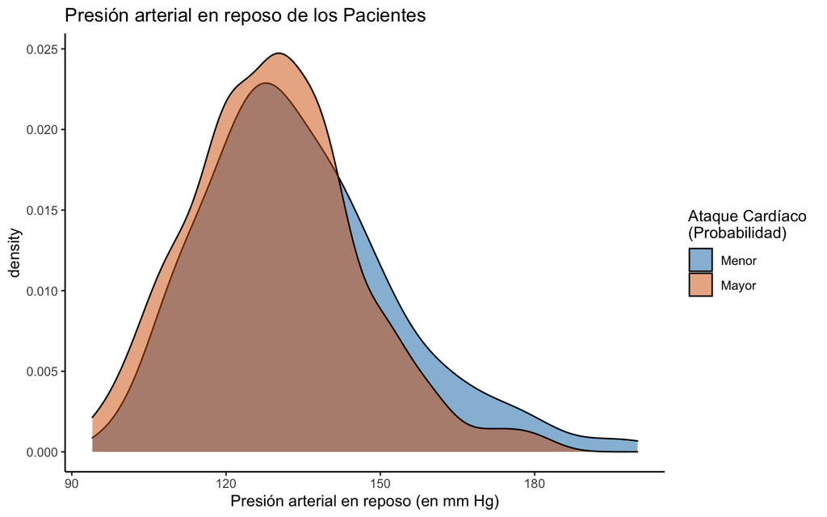

```r
ggplot(data = heart,
       aes(x = trtbps, fill = as.character(output))) +
  geom_density(alpha=0.5) +
  scale_fill_manual(label = c("0"="Menor","1"="Mayor"),
                    values = c("0"="#0072B2","1"="#D55E00")) +
  theme_classic() +
  labs(title = "Presión arterial en reposo de los Pacientes",
       x="Presión arterial en reposo (en mm Hg)",
       fill="Ataque Cardíaco \n(Probabilidad)")
```

¿Cómo se relaciona la presión arterial en reposo (**trtbps**) del paciente con un ataque al corazón?  
No se observa una tendencía clara de la presión arterial en reposo con la probabilidad de sufrir un ataque cardíaco (según la proporción y el set de datos).

*Conclusiones*

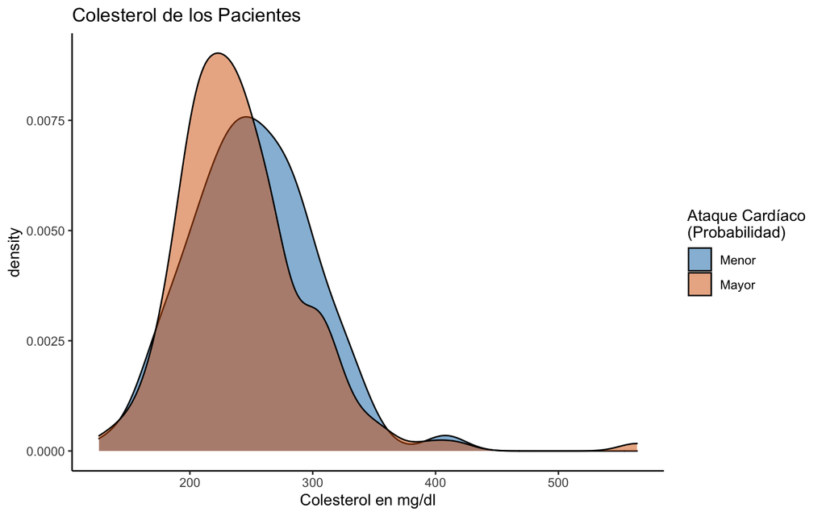

```r
ggplot(data = heart,
       aes(x = chol, fill = as.character(output))) +
  geom_density(alpha=0.5) +
  scale_fill_manual(label = c("0"="Menor","1"="Mayor"),
                    values = c("0"="#0072B2","1"="#D55E00")) +
  theme_classic() +
  labs(title = "Colesterol de los Pacientes",
       x="Colesterol en mg/dl",
       fill="Ataque Cardíaco \n(Probabilidad)")
```

*Conclusiones*

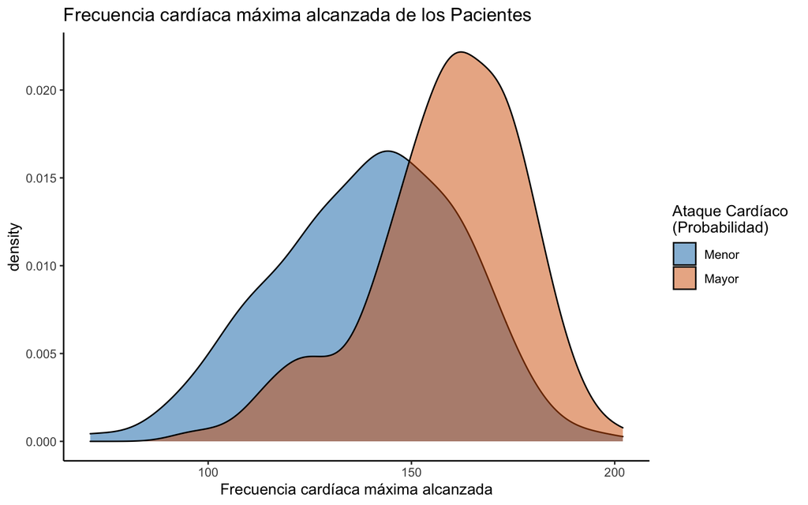

```r
ggplot(data = heart,
       aes(x = thalachh, fill = as.character(output))) +
  geom_density(alpha=0.5) +
  scale_fill_manual(label = c("0"="Menor","1"="Mayor"),
                    values = c("0"="#0072B2","1"="#D55E00")) +
  theme_classic() +
  labs(title = "Frecuencia cardíaca máxima alcanzada de los Pacientes",
       x="Frecuencia cardíaca máxima alcanzada",
       fill="Ataque Cardíaco \n(Probabilidad)")
```

¿Cómo se relaciona la frecuencia cardíaca máxima alcanzada (**thalach**) del paciente con un ataque al corazón?  
Las personas con una frecuencia cardíaca máxima alcanzada >150 tienen una mayor probabilidad de sufrir un ataque cardíaco (según la proporción y el set de datos).

*Conclusiones*

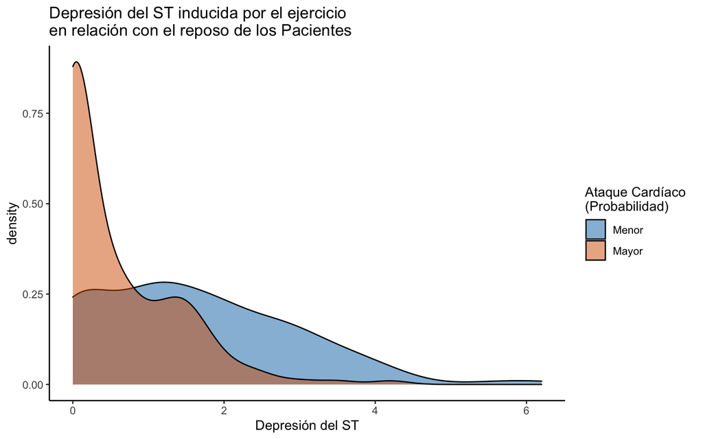

```r
ggplot(data = heart,
       aes(x = oldpeak, fill = as.character(output))) +
  geom_density(alpha=0.5) +
  scale_fill_manual(label = c("0"="Menor","1"="Mayor"),
                    values = c("0"="#0072B2","1"="#D55E00")) +
  theme_classic() +
  labs(title = "Depresión del ST inducida por el ejercicio \nen relación con el reposo de los Pacientes",
       x="Depresión del ST",
       fill="Ataque Cardíaco \n(Probabilidad)")
```

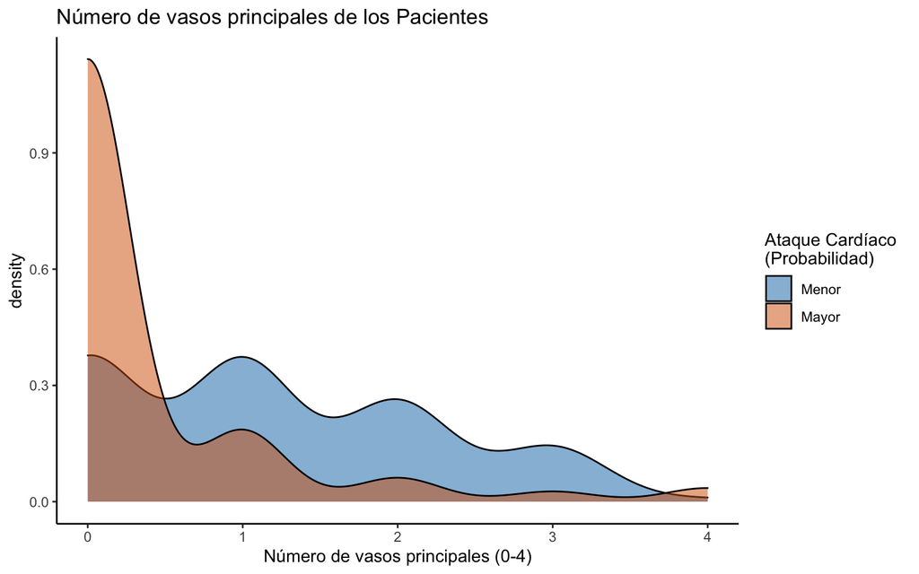

```r
ggplot(data = heart,
       aes(x = caa, fill = as.character(output))) +
  geom_density(alpha=0.5) +
  scale_fill_manual(label = c("0"="Menor","1"="Mayor"),
                    values = c("0"="#0072B2","1"="#D55E00")) +
  theme_classic() +
  labs(title = "Número de vasos principales de los Pacientes",
       x="Número de vasos principales (0-4)",
       fill="Ataque Cardíaco \n(Probabilidad)")
```

Las personas con menos vasos principales tienen muchas más probabilidades de sufrir un ataque cardíaco (según la proporción y el set de datos).

*Conclusiones*

## 3.3 Visualizando Variables Categóricas

A continuación revisaremos cómo se distribuyen las variables categóricas del set de datos **heart**.

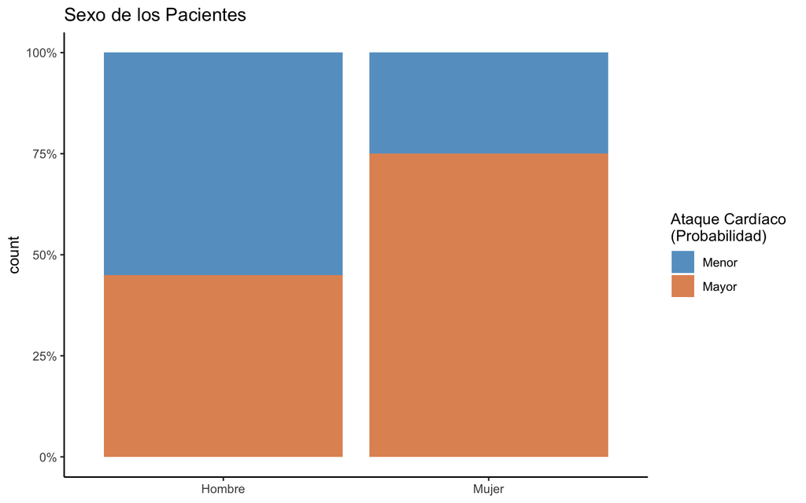

```r
ggplot(data = heart,
       aes(x = sex, fill = as.character(output))) +
  geom_bar(alpha=0.7, position = "fill") +
  scale_y_continuous(labels = scales::percent) +
  scale_fill_manual(label = c("0"="Menor","1"="Mayor"),
                    values = c("0"="#0072B2","1"="#D55E00")) +
  theme_classic() +
  labs(title = "Sexo de los Pacientes",
       x=NULL,
       fill="Ataque Cardíaco \n(Probabilidad)")
```

En este caso es necesario generar una modificación a los valores debido a que los grupos muestran distintos tamaños lo que dificulta la interpretación de los resultados, para ello ocuparemos la opción de posición `position = "fill"` en la capa o objeto geom `geom_bar(...)`. Adicionalmente, con la función `scale_y_continuous(labels = scales::percent)` podemos modificar la escala y cambiarla desde proporción a porcentajes, lo que facilitará la interpretación y mejora la estética del gráfico.

*Consejos*

¿Cómo se relaciona el sexo (**sex**) del paciente con un ataque al corazón?  
Las mujeres tienen más probabilidades de tener problemas cardíacos que los hombres (según la proporción y el set de datos).

*Conclusiones*

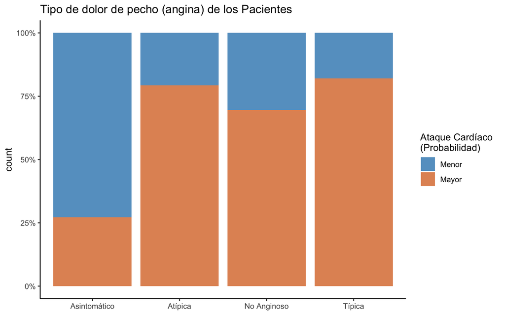

```r
ggplot(data = heart %>%
         mutate(cp = recode(cp, "0"="Asintomático","1"="Típica","2"="Atípica","3"="No Anginoso")),
       aes(x = cp, fill = as.character(output))) +
  geom_bar(alpha=0.7, position = "fill") +
  scale_y_continuous(labels = scales::percent) +
  scale_fill_manual(label = c("0"="Menor","1"="Mayor"),
                    values = c("0"="#0072B2","1"="#D55E00")) +
  theme_classic() +
  labs(title = "Tipo de dolor de pecho (angina) de los Pacientes",
       x=NULL,
       fill="Ataque Cardíaco \n(Probabilidad)")
```

Con la función `mutate(...)` podemos modificar (o crear) una columna, mientras que con la función `recode(...)` podemos reasignar los valores dentro de una determinada columna. En este caso es necesario generar una modificación, puesto que los valores se encuentran como un código númerico, lo que dificulta la interpretación de los resultados.

*Consejos*

Pacientes con dolor anginoso típico, atípico y no anginoso muestran una alta proporción de problemas cardíacos (según el set de datos).

*Conclusiones*

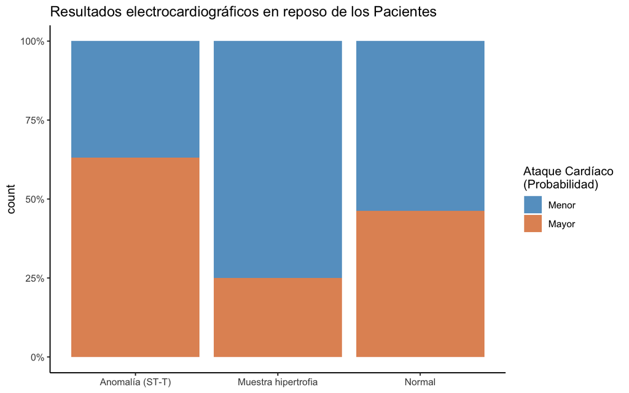

```r
ggplot(data = heart %>%
         mutate(restecg = recode(restecg, "0"="Normal","1"="Anomalía (ST-T)","2"="Muestra hipertrofia")),
       aes(x = restecg, fill = as.character(output))) +
  geom_bar(alpha=0.7, position = "fill") +
  scale_y_continuous(labels = scales::percent) +
  scale_fill_manual(label = c("0"="Menor","1"="Mayor"),
                    values = c("0"="#0072B2","1"="#D55E00")) +
  theme_classic() +
  labs(title = "Resultados electrocardiográficos en reposo de los Pacientes",
       x=NULL,
       fill="Ataque Cardíaco \n(Probabilidad)")
```

Con una anomalia ST-T del electrocardiográficos en reposo se observan una mayores proporción de problemas cardíacos (según el set de datos).

*Conclusiones*

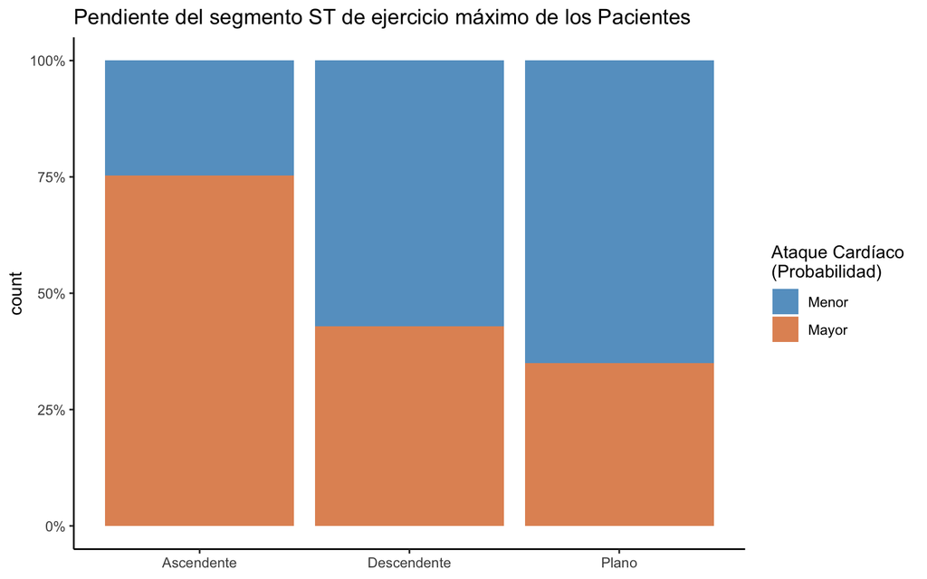

```r
ggplot(data = heart %>%
         mutate(slp = recode(slp, "0"="Descendente","1"="Plano","2"="Ascendente")),
       aes(x = slp, fill = as.character(output))) +
  geom_bar(alpha=0.7, position = "fill") +
  scale_y_continuous(labels = scales::percent) +
  scale_fill_manual(label = c("0"="Menor","1"="Mayor"),
                    values = c("0"="#0072B2","1"="#D55E00")) +
  theme_classic() +
  labs(title = "Pendiente del segmento ST de ejercicio máximo de los Pacientes",
       x=NULL,
       fill="Ataque Cardíaco \n(Probabilidad)")
```

Con una pendiente del segmento ST de ejercicio máximo ascendente se observan una mayores proporción de problemas cardíacos (según el set de datos).

*Conclusiones*

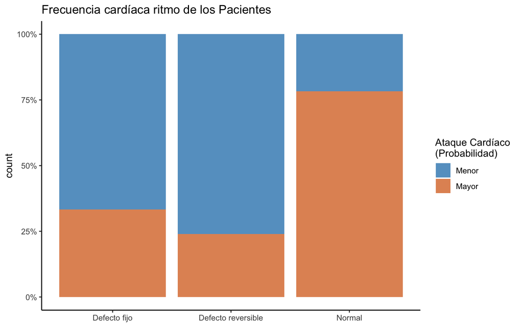

```r
ggplot(data = heart %>%
         filter(thall != 0) %>%
         mutate(thall = recode(thall, "1"="Defecto fijo","2"="Normal","3"="Defecto reversible")),
       aes(x = thall, fill = as.character(output))) +
  geom_bar(alpha=0.7, position = "fill") +
  scale_y_continuous(labels = scales::percent) +
  scale_fill_manual(label = c("0"="Menor","1"="Mayor"),
                    values = c("0"="#0072B2","1"="#D55E00")) +
  theme_classic() +
  labs(title = "Frecuencia cardíaca ritmo de los Pacientes",
       x=NULL,
       fill="Ataque Cardíaco \n(Probabilidad)")
```

Con la función `filter(...)` podemos eliminar o seleccionar los valores de interes dentro de una determinada columna. En este caso es necesario eliminar las observaciones con valor “0” en la columna “thall”, puesto que corresponden a dos pacientes sin la observación. Para realizar este filtro, le hemos indicado a la función que retenga los valores distintos a “0” escribiendo el símbolo de desigualdad `!=`.

*Consejos*

En pacientes con frecuencia cardíaca (ritmo) normal se observan una mayores proporción de problemas cardíacos (según el set de datos).

*Conclusiones*

## 3.4 Visualizando Variables Agrupadas

Sobre la base de las variables contenidas en el set de datos **heart**, que ya hemos análisado de forma independiente, podríamos dirigir el análisis hacia aquellas interacciones entre variables que son relevante en el diagnóstico de un ataque al corazón. Podríamos generar algunas nuevas preguntas:

1. ¿Cuáles son las variables más importantes de nuestro análisis?
2. ¿Cómo se relaciona la edad (**age**) y el sexo (**sex**) del paciente con un ataque al corazón?
3. ¿Cómo se relaciona el sexo (**sex**) y el colesterol (**chol**) del paciente con un ataque al corazón?
4. ¿Cómo se relaciona el sexo (**sex**) y la presión arterial en reposo (**trtbps**) del paciente con un ataque al corazón?
5. ¿Cómo se relaciona el sexo (**sex**) y la frecuencia cardíaca máxima alcanzada (**thalach**) del paciente con un ataque al corazón?

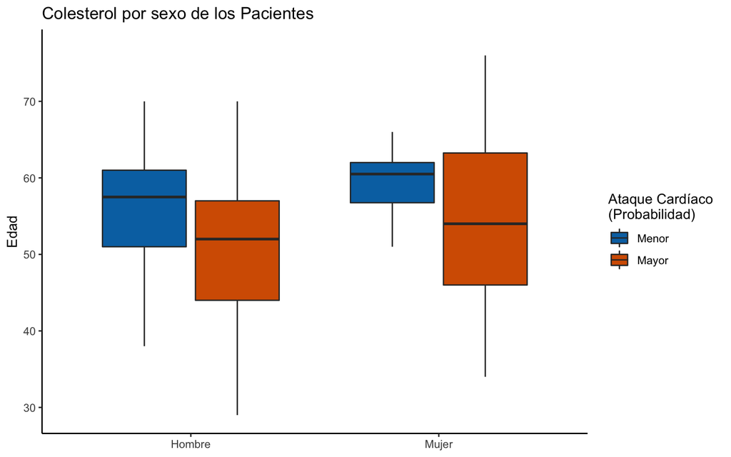

```r
ggplot(data = heart,
       aes(x = sex,
           y = age,
           fill = as.character(output))) +
  geom_boxplot(outlier.shape = NA) +
  scale_fill_manual(label = c("0"="Menor","1"="Mayor"),
                    values = c("0"="#0072B2","1"="#D55E00")) +
  theme_classic() +
  labs(title = "Colesterol por sexo de los Pacientes",
       y="Edad",
       x=NULL,
       fill="Ataque Cardíaco \n(Probabilidad)")
```

¿Cómo se relaciona la edad (**age**) y el sexo (**sex**) del paciente con un ataque al corazón?  
En pacientes hombres y mujeres más jovenes se observan mayores problemas cardíacos (según el set de datos).

*Conclusiones*

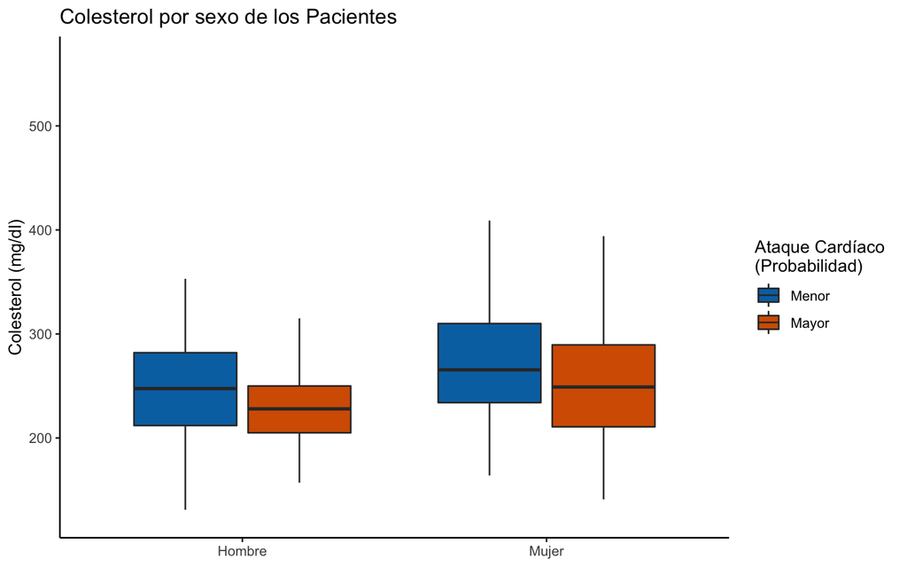

```r
ggplot(data = heart,
       aes(x = sex,
           y = chol,
           fill = as.character(output))) +
  geom_boxplot(outlier.shape = NA) +
  scale_fill_manual(label = c("0"="Menor","1"="Mayor"),
                    values = c("0"="#0072B2","1"="#D55E00")) +
  theme_classic() +
  labs(title = "Colesterol por sexo de los Pacientes",
       y="Colesterol (mg/dl)",
       x=NULL,
       fill="Ataque Cardíaco \n(Probabilidad)")
```

¿Cómo se relaciona el sexo (**sex**) y el colesterol (**chol**) del paciente con un ataque al corazón?  
En Hombres y mujeres menores valores de colesterol se observan en pacientes con problemas cardíacos (según el set de datos).

*Conclusiones*

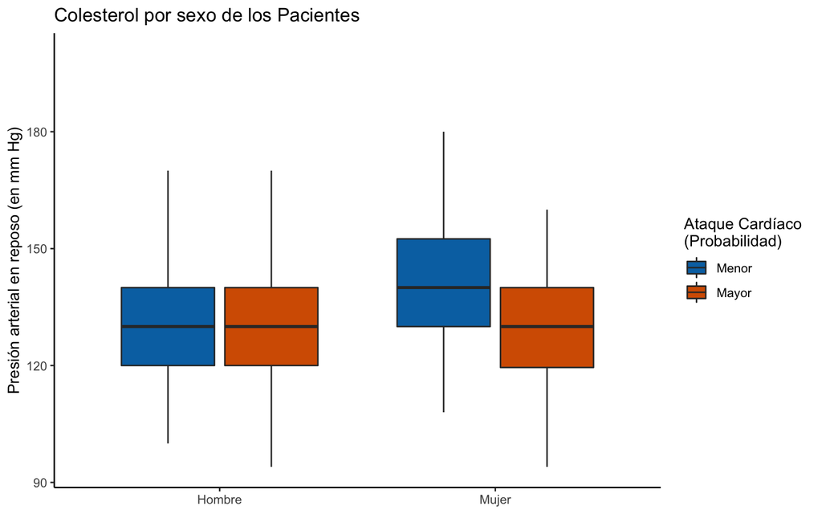

```r
ggplot(data = heart,
       aes(x = sex,
           y = trtbps,
           fill = as.character(output))) +
  geom_boxplot(outlier.shape = NA) +
  scale_fill_manual(label = c("0"="Menor","1"="Mayor"),
                    values = c("0"="#0072B2","1"="#D55E00")) +
  theme_classic() +
  labs(title = "Colesterol por sexo de los Pacientes",
       y="Presión arterial en reposo (en mm Hg)",
       x=NULL,
       fill="Ataque Cardíaco \n(Probabilidad)")
```

¿Cómo se relaciona el sexo (**sex**) y la presión arterial en reposo (**trtbps**) del paciente con un ataque al corazón?  
En pacientes mujeres con menos problemas cardíacos se observa una mayor presión arterial en reposo (en mm Hg) (según el set de datos).

*Conclusiones*

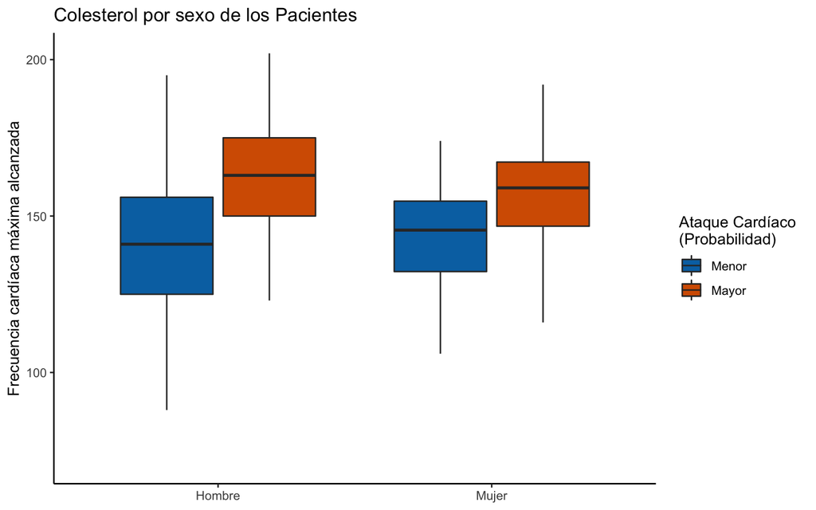

```r
ggplot(data = heart,
       aes(x = sex,
           y = thalachh,
           fill = as.character(output))) +
  geom_boxplot(outlier.shape = NA) +
  scale_fill_manual(label = c("0"="Menor","1"="Mayor"),
                    values = c("0"="#0072B2","1"="#D55E00")) +
  theme_classic() +
  labs(title = "Colesterol por sexo de los Pacientes",
       y="Frecuencia cardíaca máxima alcanzada",
       x=NULL,
       fill="Ataque Cardíaco \n(Probabilidad)")
```

¿Cómo se relaciona el sexo (**sex**) y la frecuencia cardíaca máxima alcanzada (**thalach**) del paciente con un ataque al corazón?  
En Hombres y mujeres una mayor frecuencia cardíaca máxima alcanzada se asocia con problemas cardíacos (según el set de datos).

*Conclusiones*

# 4 Inferencia Estadística